[figure not shown]

本版本正在測試階段，如有任何問題請回報

資料倉儲科 李嘉桓 #2134

# **使用說明**

- 此平台建議有初階R語言能力者使用，初學者建議使用國泰學習網[R與Python教育訓練](https://cathay.elearn.com.tw/dist/index.html#/learning-passport/incomplete-courses/course-info/9608351)完成初階課程。
- 請將語法複製至本機Rstudio或server版上使用執行(不同環境kernel可能會有所不同)，將要執行的程式碼選取，按鍵盤Ctrl+Enter執行語法。
- 若出現紅色指示圖案，為必要執行語法，不用修改直接執行即可。

[figure not shown]

- 若出現綠色指示圖案，為必要執行語法，但須根據需求修改部分內容執行。

[figure not shown]

- 每一台電腦的R版本不一樣，預設套件也不同，若跳出缺少套件的訊息，請自行安裝相關套件。
- 建議將文件建立在R根目錄下開一個新資料夾當工作環境。
- 以下以Kaggle中[Default of Credit Card Clients Dataset](https://www.kaggle.com/uciml/default-of-credit-card-clients-dataset/home)資料作為範例。

# **環境設定**

- 清理工作環境，避免環境存留資訊佔用記憶體空間。
- 載入所需package套件，若無則自動安裝。
- 設定工作路徑，沒特別設定則以當前環境當作，也可以在Rstudio右下方的Files頁自行設定路徑。

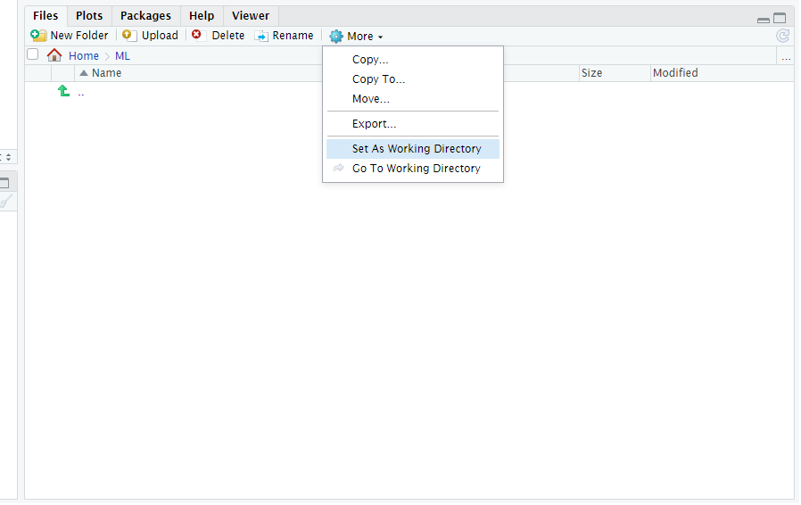

```r
rm(list = ls())

if (!require("ggplot2")) install.packages("ggplot2")
library('ggplot2')
if (!require("caret")) install.packages("caret")
library('caret')
if (!require("doParallel")) install.packages("doParallel")
library('doParallel')
if (!require("MLmetrics")) install.packages("MLmetrics")
library('MLmetrics')

set.seed(100)
path = getwd()
# path = '~/ML' # 自定義路徑
dir.create(file.path(path, "model"), showWarnings = FALSE) # model儲存位置
gc()
```

```
##           used  (Mb) gc trigger  (Mb) max used  (Mb)
## Ncells 2163566 115.6    3205452 171.2  2637877 140.9
## Vcells 3128082  23.9    4730564  36.1  3874943  29.6
```

# **資料處理**

## 檔名設定

- **TrainDataFile**為訓練資料檔名，**TestDataFile**為測試資料檔名，建議使用csv檔放置環境路徑。
- **KeyColumn**為資料識別欄位名稱，通常為key且不會重複的值，如ID、保單號碼。
- **TargetColumn**為應變數Y的欄位名稱。
- **OutputAnswer**為要產出結果的檔名。
- **MissingTypes**為讀取空字串先用NA表示。

[figure not shown]

```r
TrainDataFile = 'train.csv'
TestDataFile  = 'test.csv'
KeyColumn  = 'ID'
TargetColumn  = 'default.payment.next.month'
OutputAnswer  = 'outputdata'
MissingTypes = c("", "NA")
```

## 資料讀取

- 資料編碼預測為UTF-8，如有亂碼或讀取異常請自行轉碼或找資服求助。
- 訓練資料及測試資料的欄位數要一樣，且欄位內格式相同，測試資料可以缺少應變數Y欄位。
- 模型應變數Y值欄位可以在最前面或最後面，不影響運算。
- 資料前處理可以先使用SAS-EG進行探勘。

```r
TrainData = read.csv(paste0(path,'/',TrainDataFile), header = T, sep=",", na.strings = MissingTypes)
TestData = read.csv(paste0(path,'/',TestDataFile), header = T, sep=",", na.strings = MissingTypes)
```

- 如要觀察資料樣貌及型態，可執行下面語法。

```r
str(TrainData)
str(TestData)
head(TrainData,5)
head(TestData,5)
summary(TrainData)
summary(TestData)
```

## 型態轉換

- R的特徵型態分為數值(numeric)、整數(integer)、類別(factor)、日期(Date)、文字(character)。
- 數值與整數差異在特徵因子是否有小數點，如理賠次數為整數、身高體重為數值。
- 類別為性別、職業、學歷等離散型變數。
- 日期欄位建議轉為結構化的年月日連續型變數，如年齡、距離最後一次投保時間，**分析上會移除日期欄位變數**。
- 文字欄位通常為無分析意義的資訊，如ID、保單號碼、電話，**分析上會移除文字欄位變數**。

**請補上要進行變數轉換的欄位，若無填寫則根據系統預設進行處理，可以先使用str(TrainData)看目前預設的欄位型態。**

[figure not shown]

```r
numeric_col = c('') # names(TrainData[12:23])
integer_col = c('')
factor_col = c('SEX','EDUCATION','MARRIAGE','PAY_0','PAY_2','PAY_3','PAY_4','PAY_5','PAY_6','default.payment.next.month')
Date_col = c('')
character_col = c('ID') # c('ID','POLICY_NO','APPLY_NO','EMAIL','PHONE')
```

- 進行型態轉換。

```r
typechange = function(dataset,KeyColumn,numeric_col,integer_col,factor_col,Date_col,character_col){
  dataset = as.data.frame(dataset)
  if(sum(numeric_col!="")>0) dataset[numeric_col] = lapply(dataset[numeric_col], as.numeric)
  if(sum(integer_col!="")>0) dataset[integer_col] = lapply(dataset[integer_col], as.integer)
  if(sum(factor_col!="")>0) dataset[factor_col] = lapply(dataset[factor_col], as.factor)
  Unikey = dataset[[KeyColumn]]
  dataset = dataset[,-which(colnames(dataset) %in% c(Date_col,character_col))]
  dataset = as.data.frame(cbind(Unikey,dataset))
  return(dataset)
}

TrainData = typechange(TrainData,KeyColumn,numeric_col,integer_col,factor_col,Date_col,character_col)
TestData = typechange(TestData,KeyColumn,numeric_col,integer_col,factor_col,Date_col,character_col)
```

- 確認訓練資料型態。

```r
str(TrainData[,-1])
```

```
## 'data.frame':    24000 obs. of  24 variables:
##  $ LIMIT_BAL                 : num  180000 190000 360000 290000 30000 50000 320000 260000 80000 20000 ...
##  $ SEX                       : Factor w/ 2 levels "1","2": 1 1 1 2 2 1 1 1 2 2 ...
##  $ EDUCATION                 : Factor w/ 7 levels "0","1","2","3",..: 3 4 3 3 3 4 3 2 4 6 ...
##  $ MARRIAGE                  : Factor w/ 4 levels "0","1","2","3": 3 2 2 3 2 2 2 3 2 4 ...
##  $ AGE                       : int  26 44 28 54 51 52 39 34 40 35 ...
##  $ PAY_0                     : Factor w/ 11 levels "-2","-1","0",..: 3 4 1 1 3 4 3 3 2 3 ...
##  $ PAY_2                     : Factor w/ 11 levels "-2","-1","0",..: 3 2 2 1 3 5 3 3 3 3 ...
##  $ PAY_3                     : Factor w/ 11 levels "-2","-1","0",..: 3 5 5 1 3 5 2 3 3 3 ...
##  $ PAY_4                     : Factor w/ 11 levels "-2","-1","0",..: 3 3 5 1 3 3 2 3 3 3 ...
##  $ PAY_5                     : Factor w/ 10 levels "-2","-1","0",..: 3 3 1 1 3 3 3 1 3 3 ...
##  $ PAY_6                     : Factor w/ 10 levels "-2","-1","0",..: 3 3 1 1 3 4 3 1 3 3 ...
##  $ BILL_AMT1                 : num  171041 -1600 0 -68 10874 ...
##  $ BILL_AMT2                 : num  111580 2400 2500 -68 11896 ...
##  $ BILL_AMT3                 : num  71902 2184 2500 -68 12906 ...
##  $ BILL_AMT4                 : num  10045 2184 0 675 13162 ...
##  $ BILL_AMT5                 : num  10484 2184 0 -6 13438 ...
##  $ BILL_AMT6                 : num  10816 0 0 2168 13705 ...
##  $ PAY_AMT1                  : num  5000 4000 2500 0 1205 ...
##  $ PAY_AMT2                  : num  3340 0 0 0 1215 ...
##  $ PAY_AMT3                  : num  500 0 0 743 471 ...
##  $ PAY_AMT4                  : num  1000 0 0 0 488 ...
##  $ PAY_AMT5                  : num  1000 0 0 2174 491 ...
##  $ PAY_AMT6                  : num  416 0 0 972 508 ...
##  $ default.payment.next.month: Factor w/ 2 levels "0","1": 1 1 1 1 1 1 1 1 1 1 ...
```

## 移除異常欄位

- 找出應變數為空或為缺失的資料，跑出來結果應該為沒資料，若有請重新確認訓練資料應變數。

```r
Y_ind = TrainData[[TargetColumn]] == '' | is.na(TrainData[[TargetColumn]])
print(paste("應變數異常筆數為",sum(Y_ind)))
```

```
## [1] "應變數異常筆數為 0"
```

```r
TrainData[Y_ind,'Unikey'] # 顯示有異常的資料key
```

```
## integer(0)
```

- 移除都是同一值及全為空的欄位。

```r
clearNA = function(dataset){
  dataset = as.data.frame(dataset)
  ind_col = apply(dataset, 2,function(x) all(is.na(x)|x==''))
  if(sum(ind_col)>0) dataset = dataset[,-which(ind_col)]
  return(dataset)
}

TrainData = clearNA(TrainData)
```

## 填補缺失值

- 以下使用訓練資料進行補值示範。
- 若測試資料也需要補值，請將補值語法的TrainData改為TestData。

**補缺時值方法很多種，以下為選用模式，請根據需求進行缺失補值處理。**

```r
apply(TrainData[,-1], 2,function(x) sum(is.na(x))) # 列出欄位有缺失值的數量
```

```
##                  LIMIT_BAL                        SEX
##                          0                          0
##                  EDUCATION                   MARRIAGE
##                          0                          0
##                        AGE                      PAY_0
##                          0                          0
##                      PAY_2                      PAY_3
##                          0                          0
##                      PAY_4                      PAY_5
##                          0                          0
##                      PAY_6                  BILL_AMT1
##                          0                          0
##                  BILL_AMT2                  BILL_AMT3
##                          0                          0
##                  BILL_AMT4                  BILL_AMT5
##                          0                          0
##                  BILL_AMT6                   PAY_AMT1
##                          0                          0
##                   PAY_AMT2                   PAY_AMT3
##                          0                          0
##                   PAY_AMT4                   PAY_AMT5
##                          0                          0
##                   PAY_AMT6 default.payment.next.month
##                          0                          0
```

#### 1. 移除有遺漏值的資料

- 只要一筆資料中有缺失值，則移除整筆資料。
- 此方法可能造成資訊損失。

```r
TrainData = TrainData[complete.cases(TrainData), ]
```

#### 2. 用「平均數」或「中位數」補值

- 將連續行欄位，用平均或眾數補值。
- 此方法可以讓變數平均與原始資料不變。

```r
# 以LIMIT_BAL為例
TrainData$LIMIT_BAL[is.na(TrainData$LIMIT_BAL)] = mean(TrainData$LIMIT_BAL,na.rm = T) #用平均補值
TrainData$LIMIT_BAL[is.na(TrainData$LIMIT_BAL)] = median(TrainData$LIMIT_BAL,na.rm = T) #用中位數補值
```

#### 3. 用特定值補值

- 將有缺失的資料用固定的特定值補值。
- 適用已知缺失原因的資料，如抽菸與否，缺失為沒抽菸。

```r
# 以EDUCATION為例，缺失值補為6未知（1 =研究生院，2 =大學，3 =高中，4 =其他，5 =未知，6 =未知）
TrainData$EDUCATION[is.na(TrainData$EDUCATION)] = '6'
```

- 如果類別變數factor要增加原本沒有的類別，需要先新增類別項目，再進行補值。

```r
# 以MARRIAGE新增 "4未知" 為例（1 =已婚，2 =單身，3 =其他）
levels(TrainData$MARRIAGE) = c(levels(TrainData$MARRIAGE), 4)
TrainData$MARRIAGE[is.na(TrainData$MARRIAGE)] = '4'
```

#### 4. K-Nearest Neighbours補值法

- 又稱KNN補值法，原理為找個跟自己最像的資料，複製缺少資料補值。
- 可以一次對所有欄位補值。
- 詳細說明可以參考knnImputation。

```r
library('DMwR')
TrainData = knnImputation(TrainData, k = 10)
```

#### 5. MICE補值法

- MICE法是將每個有遺漏的值當模型Y，其他值當模型X進行預測。
- MICE法可以支援多種模型算法，包含linear regression, logistic regression, cart, random forest…等。
- 詳細說明可以參考mice。

```r
library('mice')
mice.data = mice(TrainData,
                  m = 1,           # 產生m個被填補好的資料表
                  maxit = 5,       # max iteration
                  method = "cart", # 使用CART決策樹，進行遺漏值預測
                  seed = 100)      # set.seed()，令抽樣每次都一樣

TrainData = complete(mice.data,1) # 如果m有個就有m個資料集 complete(mice.data,m)
```

#### 6. 其他補值法

- 資料補植需根據需求調整，部分機器學習演算法已支援缺失值訓練，不補值也是一種方法。
- 若上述補值方式不滿意，可以參考Amelia、missForest、Hmisc、mi等，請自行研究。

## 特徵轉換

- 特徵轉換的功用是增加資料使用價值，此步驟非必要。
- 如偏斜的資料經過log轉置，可以讓分布更加均勻。過度離散的資料，可以用正規化scale讓資料收斂。
- 如果對特徵工程有研究，自行對資料加工處理。

```r
# 以LIMIT_BAL取log為例
TrainData$LIMIT_BAL = log(TrainData$LIMIT_BAL+1)
# 以LIMIT_BAL取scale為例
TrainData$LIMIT_BAL = scale(TrainData$LIMIT_BAL)
```

## 特徵工程

- 特徵工程的方法有很多，以下用最常見的主成分分析PCA做示範。
- PCA主要功用在減少變數數量，在傳統建模占很重要的步驟，但現行機器學習演算法可以解決大量變數問題，因此為非必要步驟。

```r
formula = ~ LIMIT_BAL + AGE + BILL_AMT1 + BILL_AMT2 + BILL_AMT3 + BILL_AMT4 + BILL_AMT5 + BILL_AMT6 + PAY_AMT1 + PAY_AMT2 + PAY_AMT3 + PAY_AMT4 + PAY_AMT5 + PAY_AMT6
pca = prcomp(formula ,           # 選擇變數，原則上為連續變數
              data = TrainData,   # 資料
              scale = TRUE)       # 正規化資料

pca$rotation
```

```
##                  PC1         PC2          PC3         PC4           PC5
## LIMIT_BAL 0.16684343  0.36515971 -0.305456720 -0.07794118  0.0968464242
## AGE       0.03162490  0.10980837 -0.900555406  0.20081157 -0.1147901369
## BILL_AMT1 0.37247648 -0.19259505 -0.042046061 -0.03365000  0.0636813204
## BILL_AMT2 0.38390719 -0.18017096 -0.015304606  0.04701626  0.0934909415
## BILL_AMT3 0.38972006 -0.11638367  0.047959988  0.16299088 -0.0372329750
## BILL_AMT4 0.39301068 -0.11795390  0.016532140  0.05454920  0.0127391997
## BILL_AMT5 0.38974716 -0.10616911  0.005076630 -0.10317125  0.0007330394
## BILL_AMT6 0.38154725 -0.08665105  0.016190828 -0.11519559 -0.1519820052
## PAY_AMT1  0.13364549  0.33159847  0.136918114  0.40244157  0.2096411907
## PAY_AMT2  0.11351207  0.38001783  0.239209771  0.48249370 -0.3558972904
## PAY_AMT3  0.12523541  0.34973705  0.039174918 -0.14250627 -0.0052352975
## PAY_AMT4  0.11171377  0.30516354  0.002592748 -0.67885011 -0.0243028808
## PAY_AMT5  0.11220527  0.36779765  0.098428642 -0.14365227 -0.5223376994
## PAY_AMT6  0.09858705  0.36567815  0.060292498  0.01613018  0.7042254314
##                   PC6         PC7         PC8          PC9         PC10
## LIMIT_BAL -0.09869625  0.09966733 -0.04404230 -0.840328566 -0.042674765
## AGE        0.02409675 -0.08140039  0.05828085  0.334332107 -0.007538753
## BILL_AMT1 -0.09125845  0.06100335  0.01961996 -0.011580201  0.554150804
## BILL_AMT2 -0.06045058 -0.02640869 -0.10491724  0.008863047  0.387351800
## BILL_AMT3 -0.06983104 -0.06230968  0.11597052 -0.005859468  0.128714045
## BILL_AMT4  0.10654578  0.09481575  0.01927767  0.022424232 -0.209753447
## BILL_AMT5  0.09248996 -0.05963419  0.05475896  0.033853631 -0.417489056
## BILL_AMT6 -0.01778967  0.02237087 -0.04073448  0.057088258 -0.492431659
## PAY_AMT1   0.13247585 -0.43980013 -0.64305327  0.072568060 -0.029767316
## PAY_AMT2   0.06167914 -0.17089697  0.58152760 -0.049557194  0.061119844
## PAY_AMT3   0.72286064  0.49808932 -0.06447792  0.146996855  0.158980853
## PAY_AMT4   0.07189088 -0.58863971  0.16397317  0.121393777  0.140544012
## PAY_AMT5  -0.52138595  0.30626145 -0.33020061  0.211386466  0.059220395
## PAY_AMT6  -0.36290977  0.22600150  0.27022863  0.296924520 -0.102427157
##                    PC11          PC12          PC13         PC14
## LIMIT_BAL  0.0115353935 -1.832516e-02 -0.0021000373  0.001737131
## AGE        0.0005648947  5.441602e-04 -0.0002946413  0.001030330
## BILL_AMT1 -0.4138022829  4.363076e-01  0.2356168877 -0.283635827
## BILL_AMT2 -0.0381658931 -3.402056e-01 -0.4127109975  0.596625690
## BILL_AMT3  0.4777061843 -4.978084e-01  0.1437218553 -0.518496486
## BILL_AMT4  0.5359382423  4.812973e-01  0.3111518278  0.383813695
## BILL_AMT5 -0.0791106079  2.547066e-01 -0.6805231380 -0.318365562
## BILL_AMT6 -0.5040508732 -3.441277e-01  0.4151498465  0.131216581
## PAY_AMT1  -0.0595523154  6.909035e-02  0.0581651334 -0.071967067
## PAY_AMT2  -0.1557706337  7.611380e-02 -0.0487877240  0.127291191
## PAY_AMT3  -0.0145377561 -1.187826e-01 -0.0152512330 -0.062576728
## PAY_AMT4   0.1059162202 -4.399854e-05  0.0760498613  0.054012177
## PAY_AMT5   0.1058983706  7.189852e-02 -0.0959203595 -0.022941711
## PAY_AMT6  -0.0310460336 -3.089718e-02  0.0153924677  0.010800669
```

- 檢視PCA結果，Standard deviations為特徵值開根號，Rotation為特徵向量，即各個主成份所對應的線性組合(linear combination)係數。
- 要選擇幾個主成分，可以使用Scree plot及Pareto plot輔助。
- 相關名詞解釋可以參考[Factor analysis](https://en.wikipedia.org/wiki/Factor_analysis)。

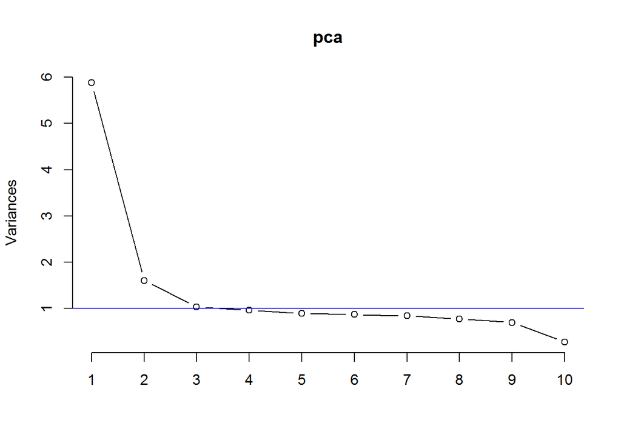

```r
# 陡坡圖(Scree plot)
plot(pca,         # 放pca
     type="line") # 用直線連結每個點

# 根據Kaiser criterion，標示出特徵值=1的地方
abline(h=1, col="blue")
```

- 將每個主成分的特徵值進行解釋運算，並累加每個主成分的解釋比例。
- 模型可以使用PCA結果進行建模，或加入原有變數建模，請使用者根據需求使用。

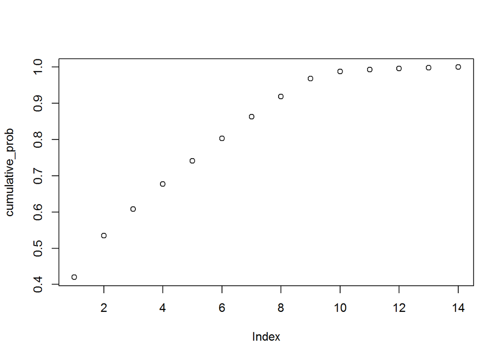

```r
var = (pca$sdev)^2 # 平方計算variance
prob = var/sum(var) # 計算解釋比例
cumulative_prob = cumsum(prob) # 累加前n個元素的值
plot(cumulative_prob)
```

# **模型訓練**

## 模型訓練預處理

- 資料預處理可以提高模型訓練的準確率，非必要執行，但**強烈建議使用**。
- 預處理會根據不同演算法有所不同(如線性回歸要排除共線性欄位、訓練資料轉為虛擬變量dummy variables)，請自由搭配使用。

#### 1. 近0變量 Zero and Near Zero-Variance 處理

- 把自變數X中，分佈差異極大的欄位排除，可以解決模型部穩定的問題(tree-based models除外)。
- 例如“是否曾經服刑”，N跟Y的資料比例為99:1，那就會排除掉該欄位。

```r
nzv = nearZeroVar(TrainData) # nzv為分佈差異大的欄位
if(length(nzv)>0) TrainData = TrainData[, -nzv] # 刪除欄位
print(names(TrainData)[nzv]) # 若沒有要刪除的則沒東西
```

```
## character(0)
```

#### 2. 轉為虛擬變量 dummy variables

- 虛擬變量會將多個因子轉為變量集，提供運算速度及準確度。
- 相關詳細說明可以參考Dummy variable。

```r
formula = paste(get('TargetColumn')," ~ .")
dummies = dummyVars(formula, data = TrainData[-1]) # 轉dummy函數
TrainData_dmy = predict(dummies, TrainData) # 建立訓練資料的虛擬變量
TestData_dmy = predict(dummies, TestData) # 建立訓練資料的虛擬變量
# dim(TrainData_dmy)
# dim(TestData_dmy)
head(TrainData_dmy[,1:5])
```

```
##   LIMIT_BAL SEX.1 SEX.2 EDUCATION.0 EDUCATION.1
## 1    180000     1     0           0           0
## 2    190000     1     0           0           0
## 3    360000     1     0           0           0
## 4    290000     0     1           0           0
## 5     30000     0     1           0           0
## 6     50000     1     0           0           0
```

#### 3. 共線性相關 Linear Dependencies

- 此方法解析自變數X是否有共線性問題，將之找出並刪除，這樣可以提高模型的穩定度(tree-based models除外)。
- 例如“BMI”及“身高&體重”就有高度線性關係，排除可以避免特徵過度解釋。

```r
comboInfo = findLinearCombos(TrainData) # 找出線性相關欄位
if(length(comboInfo$remove)>0) TrainData = TrainData[, -comboInfo$remove] # 排除相關性欄位
print(names(TrainData)[comboInfo$remove]) # 若沒有要刪除的則沒東西
```

#### 4. preProcess 函數

- 此函數可以進行 Centering 或 Scaling功能，也是提高模型穩定度的前處理方法。
- 函數功能過多可以參考preProcess。

```r
# 以center跟scale進行示範
preProcValues = preProcess(TrainData, method = c("center", "scale"))
trainTransformed = predict(preProcValues, TrainData) # 訓練資料轉換
testTransformed = predict(preProcValues, TestData) # 測試資料轉換
# 將識別欄位組回來
TrainData = data.frame(TrainData$Unikey,trainTransformed[-1])
TestData = data.frame(TestData$Unikey,testTransformed[-1])
```

#### 5. 不平衡樣本處理 Subsampling

- 有些分類問題中，會遇到正樣本與負樣本不平衡的問題，類別的頻率差異會對模型穩定有極大的影響，如理賠詐欺案件數相當稀少不易建模(decision trees之類的演算法不受影響)。
- 以下提出幾種真對不平衡樣本的處理方式，請使用者根據需求自行採用，若正負樣本比例沒有到極端不平衡，請省略此步驟。
- 下面方法可以先跑跑看，理解各個方法的優再在決定採用哪一種方式，詳細可以參考[Sampling](https://en.wikipedia.org/wiki/Oversampling_and_undersampling_in_data_analysis)。

```r
# 原本應變數樣本分佈
table(TrainData[[TargetColumn]])
```

```
##
##     0     1
## 18663  5337
```

##### 5.1 Downsampling

```r
# 若要使用請將down_train自行改為TrainData
down_train <- downSample(x = TrainData[,-which(colnames(TrainData)==TargetColumn)],
                         y = TrainData[[TargetColumn]])
names(down_train)[names(down_train)=="Class"]=get('TargetColumn')
table(down_train[[TargetColumn]])
```

```
##
##    0    1
## 5337 5337
```

##### 5.2 Upsampling

```r
# 若要使用請將up_train自行改為TrainData
up_train <- upSample(x = TrainData[,-which(colnames(TrainData)==TargetColumn)],
                     y = TrainData[[TargetColumn]])
names(up_train)[names(up_train)=="Class"]=get('TargetColumn')
table(up_train[[TargetColumn]])
```

```
##
##     0     1
## 18663 18663
```

##### 5.3 Undersampling

```r
# 若要使用請將under_train自行改為TrainData
library(ROSE)
formula = as.formula(paste(get('TargetColumn')," ~ ."))
under_train <- ovun.sample(formula, data = TrainData, method = "under")$data
table(under_train[[TargetColumn]])
```

```
##
##    0    1
## 5348 5337
```

##### 5.4 Oversampling

```r
# 若要使用請將over_train自行改為TrainData
library(ROSE)
formula = as.formula(paste(get('TargetColumn')," ~ ."))
over_train <- ovun.sample(formula, data = TrainData, method = "over")$data
table(over_train[[TargetColumn]])
```

```
##
##     0     1
## 18663 18505
```

##### 5.5 SMOTE

- 詳細可以參考SMOTE。

```r
# 若要使用請將smote_train自行改為TrainData
library(DMwR)
formula = as.formula(paste(get('TargetColumn')," ~ ."))
smote_train <- SMOTE(formula, data  = TrainData)
table(smote_train[[TargetColumn]])
```

```
##
##     0     1
## 21348 16011
```

##### 5.6 ROSE

- 詳細可以參考ROSE。

```r
# 若要使用請將rose_train自行改為TrainData
library(ROSE)
formula = as.formula(paste(get('TargetColumn')," ~ ."))
rose_train <- ROSE(formula, data  = TrainData)$data
table(rose_train[[TargetColumn]])
```

```
##
##     0     1
## 12005 11995
```

## 相關參數設定

- R一般為單核運算，為了提高運算效率，設定多核運行環境。
- 建立Control函數來控制模型訓練的方法，包含n_fold及參數的效調。
- 一開始建立模型建議先以下面default的函數進行訓練，找出最適合的演算法再進行參數調整。
- Control函數的內容請參考trainControl。

```r
# 建立多核運算環境
cl<-makeCluster(3) #建議不要超過4，自行根據硬體設備設定
registerDoParallel(cl)
#stopCluster(cl) #不使用時可以用此語法關閉多核運行

# 建立n個fold進行cross validation 以及模型的Control設定
# 如果針對演算法要詳細設定，可以各別建立Control函數
fitControl <- trainControl(## 3-fold CV
                           method = "cv",
                           number = 3 )

# 訓練資料及測試資料去除識別欄位(順便備份)
training = TrainData[-1]
testing = TestData[-1]

# 模型表現函數
report_metrics = function(method,y_ture,y_pred,y_score){
  ans = data.frame(Algorithm = method,
                   ROC_AUC = AUC(y_pred, y_ture),
                   Accuracy = Accuracy(y_pred, y_ture),
                   Precision = Precision(y_ture, y_pred, positive = '1'),
                   Recall = Recall(y_ture, y_pred, positive = '1'),
                   F1_Score = F1_Score(y_ture, y_pred, positive  = '1')
  )
 return(ans)
}
```

## 1. Generalized linear model

- 羅吉斯回歸模型，詳細請參考[GLM](https://www.rdocumentation.org/packages/rms/versions/5.1-2/topics/Glm)。

```r
# GLM模型訓練
set.seed(200)
formula = paste(get('TargetColumn')," ~ .")
formula=as.formula(formula)
glmFit <- train(formula, data = training,
                 method = "glm",
                 trControl = fitControl)
save(glmFit, file = "./model/glmFit.rda") # 儲存模型檔
glmFit
```

```
## Generalized Linear Model
##
## 24000 samples
##    23 predictor
##     2 classes: '0', '1'
##
## No pre-processing
## Resampling: Cross-Validated (3 fold)
## Summary of sample sizes: 16000, 16000, 16000
## Resampling results:
##
##   Accuracy   Kappa
##   0.8197083  0.3718826
```

```r
# 訓練資料模型表現
glm_train_pred = predict(glmFit, training)
glm_train_prob = predict(glmFit, training, type = "prob")
glm_train_report = report_metrics(glmFit$method,training[[TargetColumn]],glm_train_pred,glm_train_prob)
glm_train_report
```

```
##   Algorithm   ROC_AUC  Accuracy Precision    Recall  F1_Score
## 1       glm 0.6561265 0.8212083 0.6878592 0.3588158 0.4716168
```

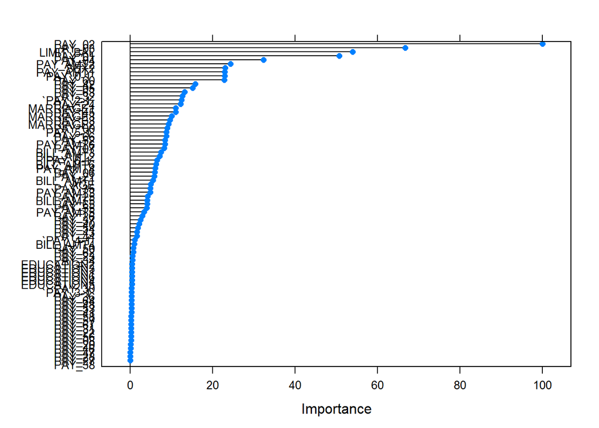

```r
# 模型重要變數
glm_imp = varImp(glmFit, scale = TRUE)
plot(glm_imp)
```

```r
# 測試資料模型表現
glm_test_pred = predict(glmFit, testing)
glm_test_prob = predict(glmFit, testing, type = "prob")
glm_test_report = report_metrics(glmFit$method,testing[[TargetColumn]],glm_test_pred,glm_test_prob)
glm_test_report
```

```
##   Algorithm   ROC_AUC  Accuracy Precision    Recall  F1_Score
## 1       glm 0.6514569 0.8226667 0.6745914 0.3494996 0.4604462
```

## 2. Decision Tree

- 決策樹模型，詳細請參考rpart。

```r
library('rpart')
# CART模型訓練
set.seed(200)
formula = paste(get('TargetColumn')," ~ .")
formula=as.formula(formula)
cartFit <- train(formula, data = training,
                 method = "rpart",
                 trControl = fitControl)
save(cartFit, file = "./model/cartFit.rda") # 儲存模型檔
cartFit
```

```
## CART
##
## 24000 samples
##    23 predictor
##     2 classes: '0', '1'
##
## No pre-processing
## Resampling: Cross-Validated (3 fold)
## Summary of sample sizes: 16000, 16000, 16000
## Resampling results across tuning parameters:
##
##   cp           Accuracy   Kappa
##   0.004871651  0.8157917  0.34183339
##   0.011335957  0.8127917  0.31520362
##   0.152332771  0.7883333  0.09814378
##
## Accuracy was used to select the optimal model using the largest value.
## The final value used for the model was cp = 0.004871651.
```

```r
# 訓練資料模型表現
cart_train_pred = predict(cartFit, training)
cart_train_prob = predict(cartFit, training, type = "prob")
cart_train_report = report_metrics(cartFit$method,training[[TargetColumn]],cart_train_pred,cart_train_prob)
cart_train_report
```

```
##   Algorithm  ROC_AUC  Accuracy Precision    Recall  F1_Score
## 1     rpart 0.635332 0.8165417 0.6975465 0.3089751 0.4282561
```

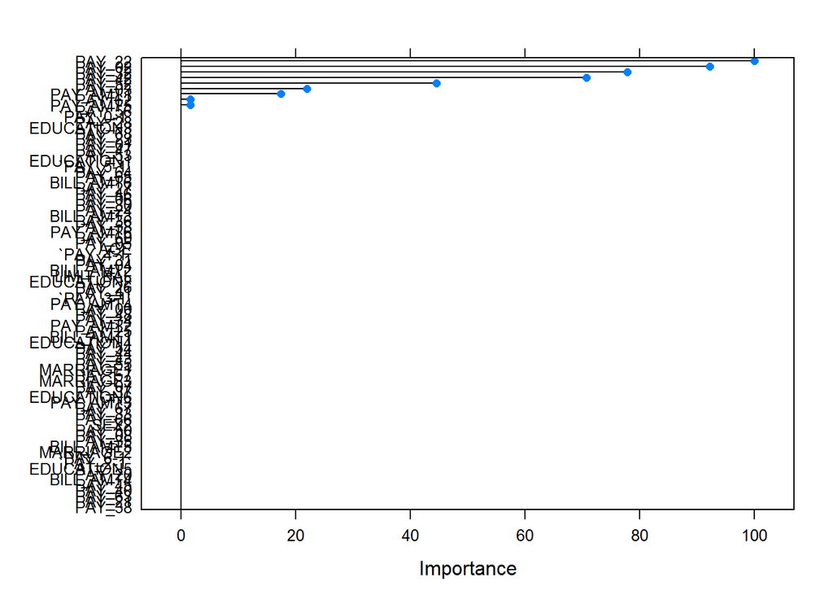

```r
# 模型重要變數
cart_imp = varImp(cartFit, scale = TRUE)
plot(cart_imp)
```

```r
# 測試資料模型表現
cart_test_pred = predict(cartFit, testing)
cart_test_prob = predict(cartFit, testing, type = "prob")
cart_test_report = report_metrics(cartFit$method,testing[[TargetColumn]],cart_test_pred,cart_test_prob)
cart_test_report
```

```
##   Algorithm   ROC_AUC  Accuracy Precision   Recall  F1_Score
## 1     rpart 0.6358428 0.8213333 0.6973913 0.308699 0.4279616
```

## 3. Random Forest

- 隨機森林模型，詳細請參考[Random Forest](https://www.rdocumentation.org/packages/randomForest/versions/4.6-14/topics/randomForest)。

```r
# RF模型訓練
set.seed(200)
formula = paste(get('TargetColumn')," ~ .")
formula=as.formula(formula)
rfFit <- train(formula, data = training,
                 method = "rf",
                 trControl = fitControl)
save(rfFit, file = "./model/rfFit.rda") # 儲存模型檔
rfFit
```

```
## Random Forest
##
## 24000 samples
##    23 predictor
##     2 classes: '0', '1'
##
## No pre-processing
## Resampling: Cross-Validated (3 fold)
## Summary of sample sizes: 16000, 16000, 16000
## Resampling results across tuning parameters:
##
##   mtry  Accuracy   Kappa
##    2    0.8015000  0.2179187
##   42    0.8144583  0.3698112
##   82    0.8135000  0.3688698
##
## Accuracy was used to select the optimal model using the largest value.
## The final value used for the model was mtry = 42.
```

```r
# 訓練資料模型表現
rf_train_pred = predict(rfFit, training)
rf_train_prob = predict(rfFit, training, type = "prob")
rf_train_report = report_metrics(rfFit$method,training[[TargetColumn]],rf_train_pred,rf_train_prob)
rf_train_report
```

```
##   Algorithm   ROC_AUC  Accuracy Precision    Recall  F1_Score
## 1        rf 0.9987686 0.9993333 0.9992494 0.9977515 0.9984999
```

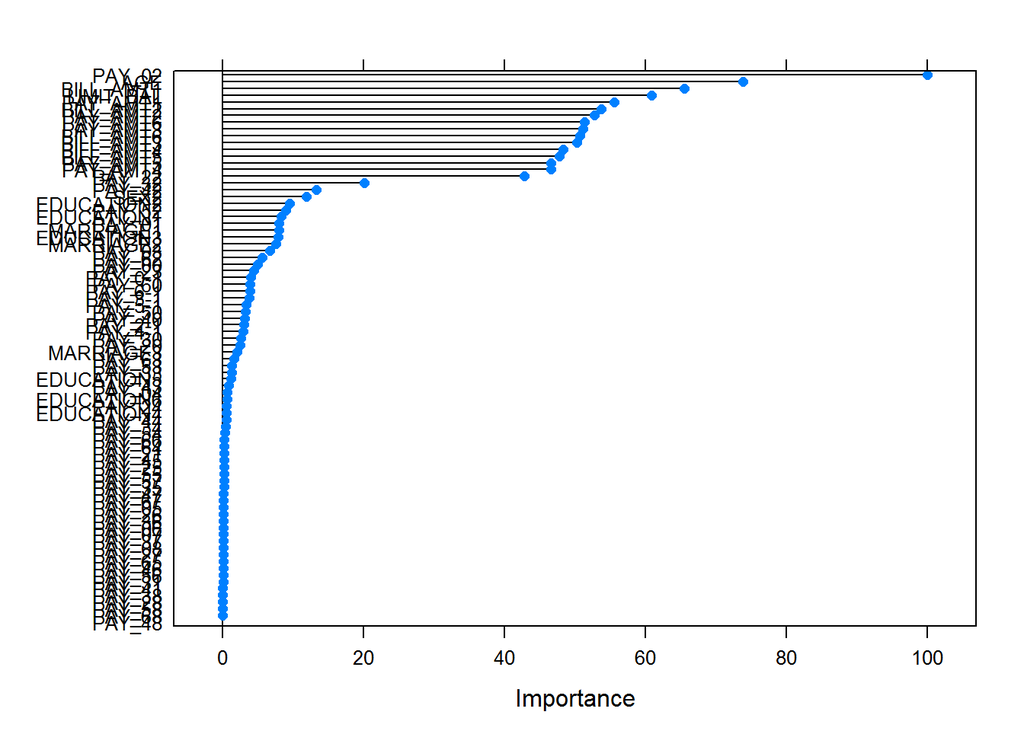

```r
# 模型重要變數
rf_imp = varImp(rfFit, scale = TRUE)
plot(rf_imp)
```

```r
# 測試資料模型表現
rf_test_pred = predict(rfFit, testing)
rf_test_prob = predict(rfFit, testing, type = "prob")
rf_test_report = report_metrics(rfFit$method,testing[[TargetColumn]],rf_test_pred,rf_test_prob)
rf_test_report
```

```
##   Algorithm   ROC_AUC  Accuracy Precision    Recall  F1_Score
## 1        rf 0.6648273 0.8226667 0.6527958 0.3864511 0.4854932
```

## 4. Stochastic Gradient Boosting

- GBM模型，詳細請參考gbm。

```r
# gbm模型訓練
set.seed(200)
library('gbm')
formula = paste(get('TargetColumn')," ~ .")
formula=as.formula(formula)
gbmFit <- train(formula, data = training,
                 method = "gbm",
                 trControl = fitControl)
save(gbmFit, file = "./model/gbmFit.rda") # 儲存模型檔
gbmFit
```

```
## Stochastic Gradient Boosting
##
## 24000 samples
##    23 predictor
##     2 classes: '0', '1'
##
## No pre-processing
## Resampling: Cross-Validated (3 fold)
## Summary of sample sizes: 16000, 16000, 16000
## Resampling results across tuning parameters:
##
##   interaction.depth  n.trees  Accuracy   Kappa
##   1                   50      0.8109583  0.2905229
##   1                  100      0.8138750  0.3253280
##   1                  150      0.8148750  0.3368671
##   2                   50      0.8167917  0.3551819
##   2                  100      0.8179167  0.3674839
##   2                  150      0.8183750  0.3717740
##   3                   50      0.8187083  0.3678052
##   3                  100      0.8196250  0.3759230
##   3                  150      0.8182500  0.3747176
##
## Tuning parameter 'shrinkage' was held constant at a value of 0.1
##
## Tuning parameter 'n.minobsinnode' was held constant at a value of 10
## Accuracy was used to select the optimal model using the largest value.
## The final values used for the model were n.trees = 100,
##  interaction.depth = 3, shrinkage = 0.1 and n.minobsinnode = 10.
```

```r
# 訓練資料模型表現
gbm_train_pred = predict(gbmFit, training)
gbm_train_prob = predict(gbmFit, training, type = "prob")
gbm_train_report = report_metrics(gbmFit$method,training$default.payment.next.month,gbm_train_pred,gbm_train_prob)
gbm_train_report
```

```
##   Algorithm   ROC_AUC  Accuracy Precision    Recall F1_Score
## 1       gbm 0.6594713 0.8212083 0.6813454 0.3681844 0.478044
```

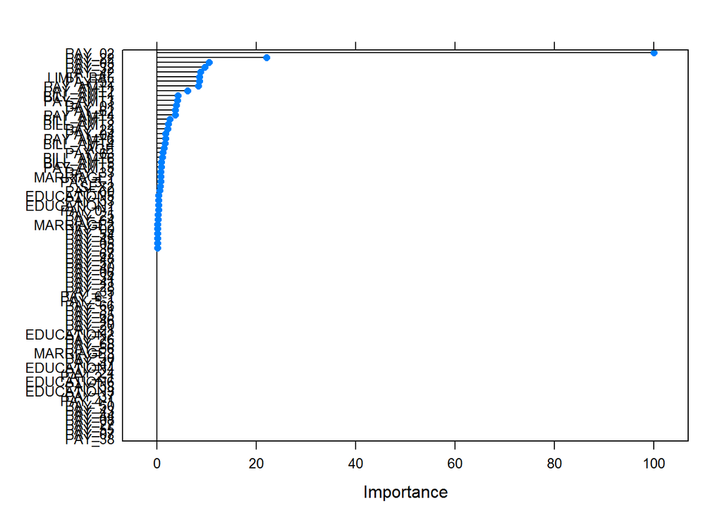

```r
# 模型重要變數
gbm_imp = varImp(gbmFit, scale = TRUE)
plot(gbm_imp)
```

```r
# 測試資料模型表現
gbm_test_pred = predict(gbmFit, testing)
gbm_test_prob = predict(gbmFit, testing, type = "prob")
gbm_test_report = report_metrics(gbmFit$method,testing$default.payment.next.month,gbm_test_pred,gbm_test_prob)
gbm_test_report
```

```
##   Algorithm ROC_AUC  Accuracy Precision    Recall  F1_Score
## 1       gbm 0.65249 0.8216667 0.6657019 0.3541186 0.4623116
```

## 5. eXtreme Gradient Boosting

- XGBoost模型，詳細請參考[xgb](https://www.rdocumentation.org/packages/xgboost/versions/0.4-4/topics/xgboost)。

```r
# XGB模型訓練
set.seed(200)
formula = paste(get('TargetColumn')," ~ .")
formula=as.formula(formula)
xgbFit <- train(formula, data = training,
                 method = "xgbTree",
                 trControl = fitControl)
save(xgbFit, file = "./model/xgbFit.rda") # 儲存模型檔
xgbFit
```

```
## eXtreme Gradient Boosting
##
## 24000 samples
##    23 predictor
##     2 classes: '0', '1'
##
## No pre-processing
## Resampling: Cross-Validated (3 fold)
## Summary of sample sizes: 16000, 16000, 16000
## Resampling results across tuning parameters:
##
##   eta  max_depth  colsample_bytree  subsample  nrounds  Accuracy
##   0.3  1          0.6               0.50        50      0.8153333
##   0.3  1          0.6               0.50       100      0.8160417
##   0.3  1          0.6               0.50       150      0.8165417
##   0.3  1          0.6               0.75        50      0.8139583
##   0.3  1          0.6               0.75       100      0.8165000
##   0.3  1          0.6               0.75       150      0.8174583
##   0.3  1          0.6               1.00        50      0.8149583
##   0.3  1          0.6               1.00       100      0.8159167
##   0.3  1          0.6               1.00       150      0.8169167
##   0.3  1          0.8               0.50        50      0.8151667
##   0.3  1          0.8               0.50       100      0.8159583
##   0.3  1          0.8               0.50       150      0.8168750
##   0.3  1          0.8               0.75        50      0.8150000
##   0.3  1          0.8               0.75       100      0.8158750
##   0.3  1          0.8               0.75       150      0.8172500
##   0.3  1          0.8               1.00        50      0.8141667
##   0.3  1          0.8               1.00       100      0.8158333
##   0.3  1          0.8               1.00       150      0.8167083
##   0.3  2          0.6               0.50        50      0.8179583
##   0.3  2          0.6               0.50       100      0.8182083
##   0.3  2          0.6               0.50       150      0.8181250
##   0.3  2          0.6               0.75        50      0.8164583
##   0.3  2          0.6               0.75       100      0.8167500
##   0.3  2          0.6               0.75       150      0.8177083
##   0.3  2          0.6               1.00        50      0.8179583
##   0.3  2          0.6               1.00       100      0.8187083
##   0.3  2          0.6               1.00       150      0.8174583
##   0.3  2          0.8               0.50        50      0.8180833
```

[output cut: 182 more lines]

```
##   0.3517938
##   0.3660549
##   0.3602431
##   0.3574991
##   0.3665467
##   0.3680104
##   0.3701365
##
## Tuning parameter 'gamma' was held constant at a value of 0
##
## Tuning parameter 'min_child_weight' was held constant at a value of 1
## Accuracy was used to select the optimal model using the largest value.
## The final values used for the model were nrounds = 50, max_depth = 3,
##  eta = 0.4, gamma = 0, colsample_bytree = 0.6, min_child_weight = 1
##  and subsample = 0.75.
```

```r
# 訓練資料模型表現
xgb_train_pred = predict(xgbFit, training)
xgb_train_prob = predict(xgbFit, training, type = "prob")
xgb_train_report = report_metrics(xgbFit$method,training$default.payment.next.month,xgb_train_pred,xgb_train_prob)
xgb_train_report
```

```
##   Algorithm   ROC_AUC  Accuracy Precision    Recall  F1_Score
## 1   xgbTree 0.6670343 0.8262083 0.7014513 0.3803635 0.4932572
```

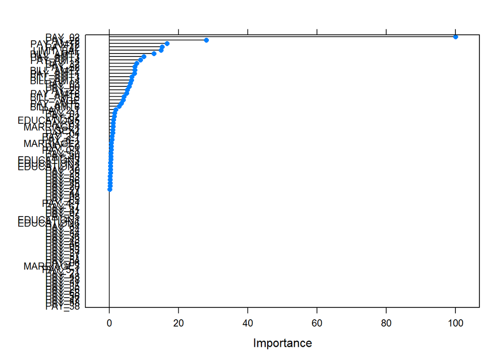

```r
# 模型重要變數
xgb_imp = varImp(xgbFit, scale = TRUE)
plot(xgb_imp)
```

```r
# 測試資料模型表現
xgb_test_pred = predict(xgbFit, testing)
xgb_test_prob = predict(xgbFit, testing, type = "prob")
xgb_test_report = report_metrics(xgbFit$method,testing$default.payment.next.month,xgb_test_pred,xgb_test_prob)
xgb_test_report
```

```
##   Algorithm   ROC_AUC Accuracy Precision   Recall  F1_Score
## 1   xgbTree 0.6541766    0.823 0.6719884 0.356428 0.4657948
```